# Group Assignment - Quarto Replication + Visualization

Author

The Boys

Published

February 26, 2026

# Introduction

This assignment is designed to introduce you to the basics of Quarto. You will learn how to create documents with headers, formatted text, lists, tables, and embed R code for data analysis. **Replicate this whole file literally and as closely as possible. However, you must change the author (group) name above, “YOUR GROUP NAME” to yours**.

# Import YAML

It is crucial to include `embed-resources: true` in the YAML header when you generate HTML files (and revealjs slides). For this document, `theme: yeti` and `code-line-numbers: true` was used.

Check out `date:` and `date-format:` options to properly format the date.

# Objectives

- Understand and apply Quarto markdown formatting
- Embed and execute R code within a Quarto document

# Quarto

When creating a Quarto document, it’s advisable to primarily work in the **Source view** rather than the **Visual view**.

# Formatting

**Bold** text

*Italicize* text

`Code` format with backticks

# Bullet Lists

- Item 1
- Item 2

# Numbered List

1. First item
2. Second item

# Tables

When creating tables, Visual mode is useful.

| Column 1 | Column 2 |
| --- | --- |
| Row 1 | Data |
| Row 2 | Data |

# Insert gifs

Include an animated image with a caption that showcases someone utterly amazed by Quarto. Note the picture is centered.

The link address: https://media.giphy.com/media/lXu72d4iKwqek/giphy.gif

[figure not shown]

Figure 1: It blows my mind!!

# Embedding R Code

Quarto allows embedding R code blocks for dynamic analysis and reporting. For below code, make sure not to print warning messages with `#| warning: false`.

For slides, including

- `auto-stretch: false` and
- `scrollable: true`

in the YAML header will ensure that all content is presented without any compression or omission of images.

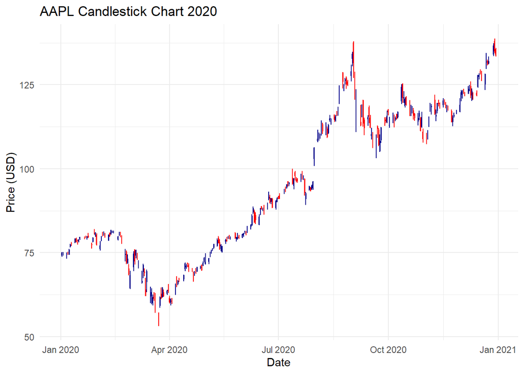

```r
library(tidyquant)
library(tidyverse)
aapl_data <- tq_get("AAPL", from = "2020-01-01", to = "2020-12-31")

# Plot candlestick chart
aapl_data %>%
  ggplot(aes(x = date, open = open, high = high, low = low, close = close)) +
  geom_candlestick() +
  theme_minimal() +
  labs(title = "AAPL Candlestick Chart 2020", x = "Date", y = "Price (USD)")
```

# Omit R code

Produce above chart without showing the code block and warning message, with `#| echo: false` and `#| warning: false`.

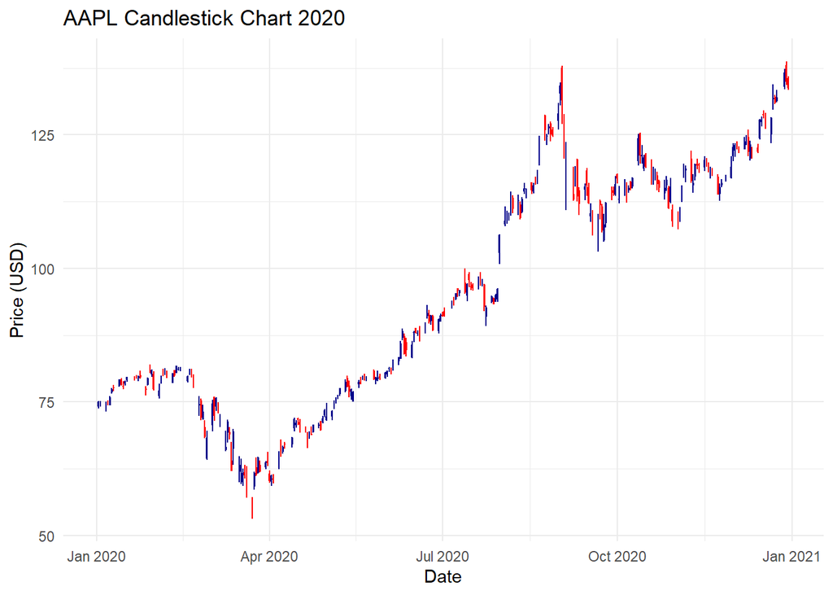